# Yelp Restaurant Health Scores Data Analysis

Chaitra Subramaniam

12/1/2018

### About the Dataset

The dataset I will be using is the Yelp data about Local Inspector Value Entry Specification (LIVES) from 2012. However, it has last been updated in August 2015 so I will be using version 2.0. https: //www.yelp.com/healthscores. The data comprises of 3 major different sub datasets:

1. Businesses: Information about the businesses including address, city, lat, lon, postal code and name.
2. Inspections: Information about scores about business and type of checkup
3. Violations: Information about how the business violated a certain regulation. This could be in text or in code and severity of violation.

### Objective

Even though the Yelp data is available for numerous counties, I picked 5 (Anchorage, Fortworth, Evanston, SF, and Boulder) as they span different coasts of the United States, have various sizes,and mean income groups.

The overarching question I want to ask is how do scores differ by county and can we find any reasons as to why they do? This is interesting because my presumption is that the more expensive the county, the better the food standards will be and therefore, a higher score. However, I want to cut out this bias and try to understand the relationship between county and score using data science.

### Load Packages

```r
library (tidyverse)
library (ggplot2)
library(dplyr)
library(gridExtra)
library(stringr)
library(lubridate)
library(data.table)
library(modelr)
```

Reading in the Data:

```r
#row.names=1 makes sure an additional index column (X) gets imported
data<-read.csv("data/processed/dataset_merged.csv",row.names = 1)
```

### Understanding the Dataset

#### Data Structure

```r
names(data)
```

```
##  [1] "business_id"     "date_inspection" "score"
##  [4] "type"            "name"            "address"
##  [7] "city"            "state"           "postal_code"
## [10] "date_violation"  "description"     "code"
## [13] "County"          "latitude"        "longitude"
## [16] "critical"
```

```r
length(names(data))
```

```
## [1] 16
```

```r
nrow(data)
```

```
## [1] 495677
```

#### Unique Businesses in the Dataset

```r
unique_businesses <- length(unique (data$business_id))
prop_unique <-(unique_businesses/nrow(data))*100
unique_businesses
```

```
## [1] 10017
```

```r
prop_unique
```

```
## [1] 2.020872
```

The proportion of unique business id’s is extremely small in the dataset (2%) which means that the same 10000 restaurants gets observed/inspected.

#### Observe the number of restaurants inspected in each county

```r
data%>%
  group_by(County,state)%>%
  summarize_each(funs(n_distinct(business_id)))%>%
  select(c("County","state","business_id"))
```

```
## `summarise_each()` is deprecated.
## Use `summarise_all()`, `summarise_at()` or `summarise_if()` instead.
## To map `funs` over all variables, use `summarise_all()`
```

```
## # A tibble: 9 x 3
## # Groups:   County [5]
##   County    state business_id
##   <fct>     <fct>       <int>
## 1 Anchorage AK            932
## 2 Boulder   CO           1266
## 3 Boulder   FL              1
## 4 Boulder   NE              1
## 5 Boulder   OK              1
## 6 Boulder   TX              4
## 7 Evanston  IL            402
## 8 Fortworth TX           1883
## 9 SF        CA           5760
```

1. After importing data for 5 counties (Anchorage, Boulder, Evanston, Fortworth, and SF), I thought initially that there would only be one state per county. But in this evaluation Boulder has 5 different ones (even though most restaurants appear in Colarado). It is interesting that they would only inspect or atleast record data for such a few restaurants in the remaining states.
2. I looked at the count of unique business_id’s for each county and state. Unsuprisingly, SF has the highest number of restaurants (almost 14x Evanston which has the lowest) because it is a more densely populated city and county. It will be interesting to see how trends in performance/scores of these restaurants differ with bigger and smaller counties.

### Types of Inspections

#### What are the different types?

```r
unique(data$type)
```

```
## [1] routine   followup  Routine   complaint initial
## Levels: Routine complaint followup initial routine
```

```r
#routine=Routine
data$type[data$type=='routine']<-'Routine'
```

#### Type per count

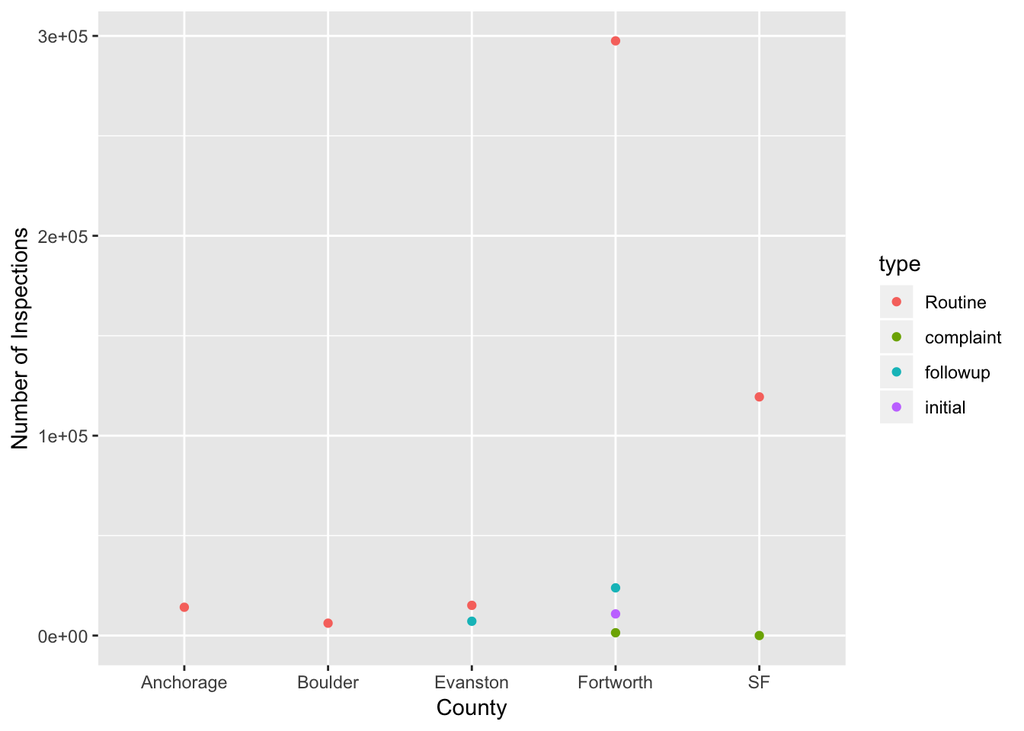

```r
data%>%
  group_by(County,type)%>%
  summarize(n=n())%>%
  ggplot(aes(x=County,y=n,color=type))+
  geom_point()+
  labs(y='Number of Inspections')
```

```r
data%>%
  group_by(County,type)%>%
  summarize(n=n())
```

```
## # A tibble: 10 x 3
## # Groups:   County [?]
##    County    type           n
##    <fct>     <fct>      <int>
##  1 Anchorage Routine    14163
##  2 Boulder   Routine     6192
##  3 Evanston  Routine    15114
##  4 Evanston  followup    7162
##  5 Fortworth Routine   297523
##  6 Fortworth complaint   1400
##  7 Fortworth followup   23873
##  8 Fortworth initial    10832
##  9 SF        Routine   119406
## 10 SF        complaint     12
```

a.Fortworth has a massive number of routine check ups compared to everything esle. It also has more follow ups than initial showing that they had to go back for check ins due to bad quality/hazards which could be why their scores were way lower.

b.Their complaints are also lower than follow ups which might show that most of the time, inspectors find out problems by their routine visits rather than by going when they get a complaint.

c.Most other check ups for the remaining counties are routine.

### Scores

First I’d like to see how these scores are graded (and how they are distributed) and then I’d like to understand what it entails to get a certain score.

#### Histogram of Scores

```r
summary(data$score)
```

```
##    Min. 1st Qu.  Median    Mean 3rd Qu.    Max.
##    0.00    9.00   18.00   37.01   82.00  200.00
```

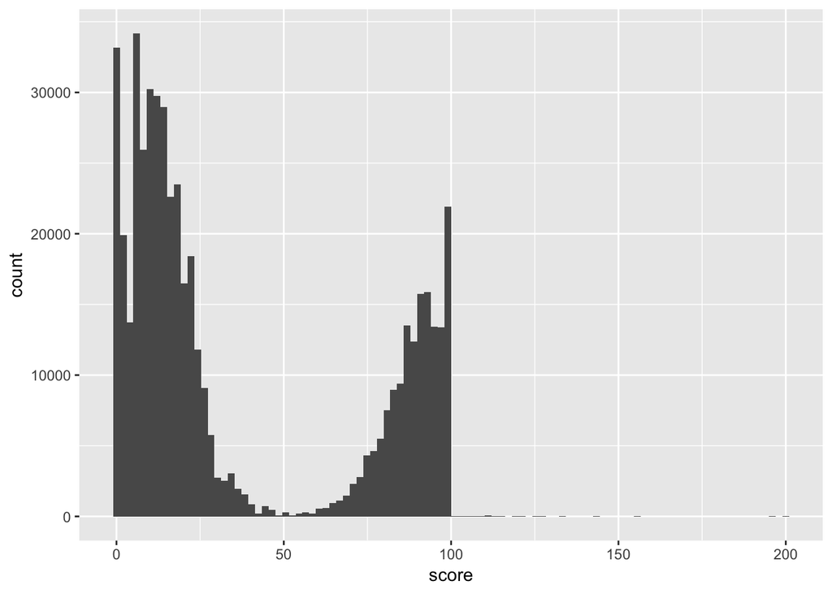

```r
data%>%
  ggplot(aes(score))+
  geom_histogram(bins=100)
```

b.The distribution of the scores are interesting because there are hardly any restaurants that are considered (“average”) or 50/100. The mean score is 37 whereas the median score is 18 so there is a huge discrepancy.

```r
data <- data%>%
  filter(score<=100)

summary(data$score)
```

```
##    Min. 1st Qu.  Median    Mean 3rd Qu.    Max.
##    0.00    9.00   18.00   36.92   82.00  100.00
```

After removing data with scores greater than hundred, nothing really changed (other than the mean slightly) so it is safe to remove those values.

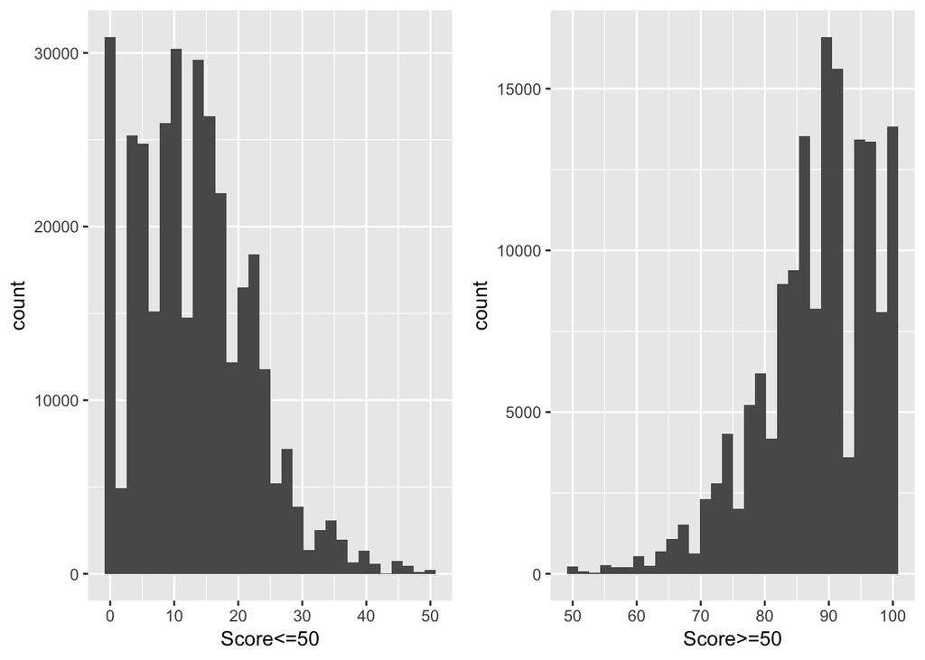

```r
p1<- data%>%
  filter(score<=50)%>%
   ggplot (aes(score))+
  geom_histogram(bins=30)+
  labs(x="Score<=50")

p2<- data%>%
  filter(score>=50)%>%
   ggplot (aes(score))+
  geom_histogram(bins=30)+
  labs(x="Score>=50")

grid.arrange(p1,p2,ncol=2)
```

a.We can view almost a symmetrical distribution. Note that these scores are not necessarily about quality of food but rather inspection of cleanliness, safety, interiors etc. which could be a reason as to why they swing one way or the other.

b.More scores lie on the left side of the 50 cutoff. A potential reason for this could be due to the fact that inspections may happen when there have been low ratings/reason for the inspection which is why they are likely to fall on the lower end.

#### 2. Distribution of Scores in each County

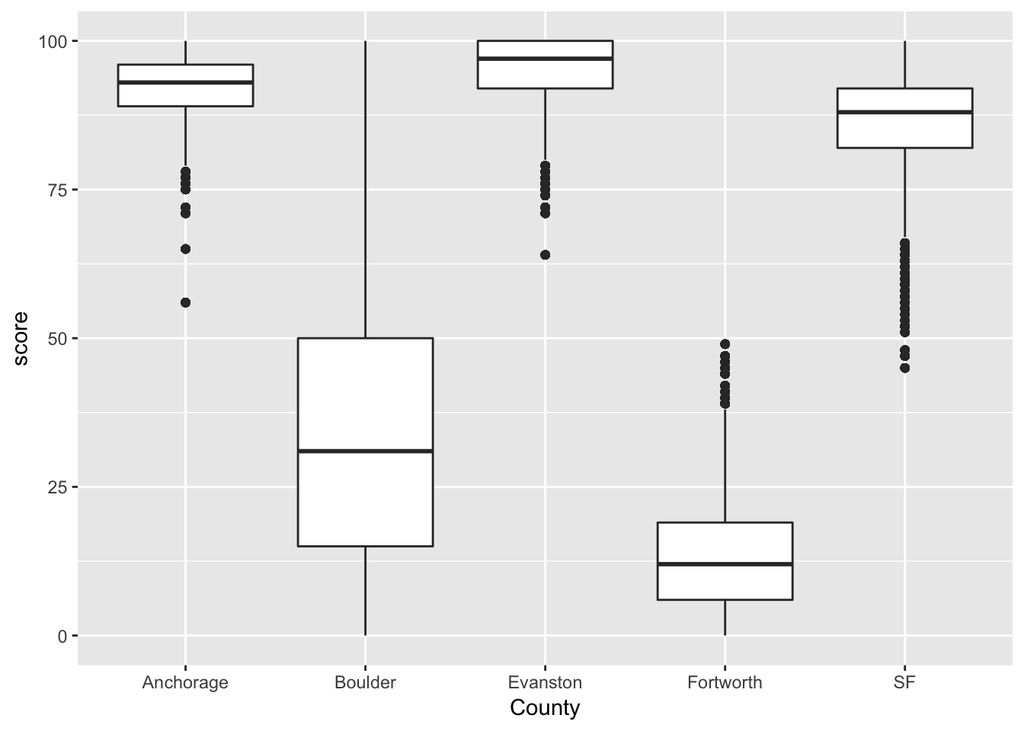

```r
data%>%
  ggplot(aes(x=County,y=score))+
  geom_boxplot()
```

a. Evanston seems to have the highest mean of scores which Fortsworth has the lowest. It is interesting that this exists because the annual household income (according to 2016 reports from Data USA) is much higher in Evanston (70k) and SF (100k) than Boulder ($60000) which is why the restaurants may be of overall higher standards. One could counter that argument by saying then logically, SF should have higher mean scores than Evanston but it doesn’t.

2. Counties with high mean scores seem to have a smaller distribution around the mean (they may consistently get pretty good scores) whereas Boulder has a much wider distribution.

#### 3. How severe are the scores?

1. The data for Evanston and Fortworth specifically have information about whether the restaurant was critical (bad) in their checkup.

```r
#Evanston

data%>%
  filter(grepl("CRITICAL",data$description))%>%
  group_by(County)%>%
  summarize(n=n())
```

```
## # A tibble: 1 x 2
##   County       n
##   <fct>    <int>
## 1 Evanston  5584
```

```r
number_critical_ev <- data%>%
  filter(grepl("CRITICAL",data$description))%>%
  group_by(County)%>%
  select(description)%>%
  nrow()
#prop critical from evanston
number_critical_ev/nrow(filter(data,data$County=='Evanston'))*100
```

```
## [1] 25.06734
```

```r
#prop critical from fortworth

number_critical_fw<- data%>%
  filter(data$critical=='Yes')%>%
  nrow()

number_critical_fw/nrow(filter(data,data$County=='Fortworth'))*100
```

```
## [1] 75.36718
```

a.Evanston’s descriptions are the only ones that have “Critical” specified in the description. We can use this to our advantage to understand how severe the inspections are for Evanston. 25% are marked critical which can be considered quite a high number (1:4 checkups are critical). This is intriguing as Evanston also got the overall highest mean scores.

b.In contrast, however, 75% of Fortworth check ups are marked critical which unsurprisingly had the lowest mean scores.

#### Description with the Score

In order to get an idea for what’s going wrong with the rest of the counties, we can look at the description for some insight. With each score, there is a description attached which can help us understand how severe the score is:

```r
unique(data$description)[1:5]
```

```
## [1] CRITICAL VIOLATION. Milk and cream in the dispenser is being held at 49 F. The products were discarded.
## [2] CRITICAL VIOLATION. The milk and cream dispenser is not working properly. The manager has agreed to stop using it until it has been serviced and will only use the other working dispenser.
## [3] A container of orange juice is being stored submerged in the ice machine. The bottle has been removed.
## [4] The top of the hash brown hot hold is soiled. Routinely clean all surfaces.
## [5] Replace torn gasket on front refrigerator
## 18103 Levels:  Multiple food containers stored in the upstairs walk-in cooler are not covered with a lid. Cover all food items placed in storage in order to prevent contamination from potential pests.  ...
```

Descriptions can be minor (like the container of the orange juice is submerged in ice etc. ) but more importantly, if they are critical, they will have CRITICAL in the string.

### Overall Top 10 common words in the descriptions given

```r
str_extract_all(data$description, boundary("word"))%>%
unlist() %>%
str_to_lower() %>%
tibble() %>%
set_names(nm='words') %>%
group_by(words) %>%
count(sort = TRUE) %>%
head(10)
```

```
## # A tibble: 10 x 2
## # Groups:   words [10]
##    words           n
##    <chr>       <int>
##  1 food       158139
##  2 violation  105033
##  3 date       102284
##  4 or         100100
##  5 corrected   98193
##  6 grp         70257
##  7 surfaces    70004
##  8 contact     69906
##  9 of          51169
## 10 facilities  50250
```

#### Top 10 common words by county

```r
get_common_words<-function(county,data){
  d <- data%>%
    filter(County==county)
  str_extract_all(d$description, boundary("word"))%>%
  unlist() %>%
  str_to_lower() %>%
  tibble() %>%
  set_names(nm='words') %>%
  group_by(words) %>%
  count(sort = TRUE) %>%
  setnames("words",paste(county,"words"))%>%
  head(5)
}

#Highly Scored County
get_common_words('SF',data)
```

```
## # A tibble: 5 x 2
##   `SF words`     n
##   <chr>      <int>
## 1 violation  98707
## 2 corrected  97933
## 3 date       97933
## 4 or         91503
## 5 food       43563
```

```r
#Worse scored county
get_common_words('Fortworth',data)
```

```
## # A tibble: 5 x 2
##   `Fortworth words`      n
##   <chr>              <int>
## 1 food              101776
## 2 grp                70257
## 3 contact            51233
## 4 surfaces           50400
## 5 facilities         38799
```

a.For a better scored county (like SF compared to Fortworth), interestingly, the most common words in SF are violation followed by corrected. A possible reason could be because the violation was corrected, leading to a higher score.

b.However, in a lower scoring county like Fortworth, the most common word is food or grp(referring to generally accepted practices) indicating that they may not be following these standards or have poor food quality.

#### Bad reviews vs. Good reviews

If we term bad reviews as scores <=30:

```r
bad_reviews<-data%>%
  filter(score<=30)

head(bad_reviews$description,n=10)
```

```
##  [1] 25. Food Contact Surfaces-Cleaned/Sanitized/Good Repair
##  [2] Proper Cold Holding temperature(41\260F/45\260F)
##  [3] Adequate handwashing facilities: Accessible & supplied, used
##  [4] No evidence of insect contamination, rodent/other animals
##  [5] Food Protection - GRP
##  [6] Floors, Walls and Ceilings - GRP
##  [7] Lighting - GRP
##  [8] Garbage and Refuse Disposal  - GRP
##  [9] 2. Cold Holding Temperature
## [10] 3. Hot Holding Temperature
## 18103 Levels:  Multiple food containers stored in the upstairs walk-in cooler are not covered with a lid. Cover all food items placed in storage in order to prevent contamination from potential pests.  ...
```

```r
str_extract_all(bad_reviews$description, boundary("word")) %>%
unlist() %>%
str_to_lower() %>%
tibble() %>%
set_names(nm='words') %>%
group_by(words) %>%
count(sort = TRUE) %>%
head(10)
```

```
## # A tibble: 10 x 2
## # Groups:   words [10]
##    words           n
##    <chr>       <int>
##  1 food        98787
##  2 grp         67759
##  3 contact     49831
##  4 surfaces    48988
##  5 facilities  37650
##  6 good        36276
##  7 other       31153
##  8 temperature 30382
##  9 of          30159
## 10 properly    27332
```

The bad reviews surprisingly don’t have terrible descriptions where there are angry reviews. This might be because they are routine steps. The most commonly used words are food or surfaces which might indicate issues with storage of the food or the temperature of the room.

And good reviews with score >= 70

```r
good_reviews<-data%>%
  filter(score>=70)

str_extract_all(good_reviews$description, boundary("word")) %>%
unlist() %>%
str_to_lower() %>%
tibble() %>%
set_names(nm='words') %>%
group_by(words) %>%
count(sort = TRUE) %>%
head(5)
```

```
## # A tibble: 5 x 2
## # Groups:   words [5]
##   words          n
##   <chr>      <int>
## 1 violation 100452
## 2 date       95007
## 3 corrected  93973
## 4 or         91778
## 5 food       53991
```

One question you could ask is why are Evanston scores >=70 marked Critical at all? Maybe scores are inflated for Evanston? This could be a stretch but I think it is a possible implication to think about.

```r
#Mean scores for all of Evanston
data%>%
  filter(County=='Evanston' && grepl("CRITICAL",data$description))%>%
  summarize(mean_score = mean(score))
```

```
##   mean_score
## 1   36.91612
```

```r
#Mean scores of the Good reviews
good_reviews%>%
  filter(County=='Evanston' && grepl("CRITICAL",data$description))%>%
  summarize(mean_score = mean(score))
```

```
##   mean_score
## 1   88.92713
```

```r
#Percentage of Good reviews from Evanston
(nrow(good_reviews%>%
  filter(County=='Evanston')))*100/nrow(good_reviews)
```

```
## [1] 14.66602
```

```r
unique(good_reviews$County)
```

```
## [1] Evanston  Anchorage SF        Boulder
## Levels: Anchorage Boulder Evanston Fortworth SF
```

#### How does when an inspection take place affect the score?

By Date of Inspection:

```r
data$date_inspection <- ymd(data$date_inspection)
data$date_violation <- ymd(data$date_violation)
```

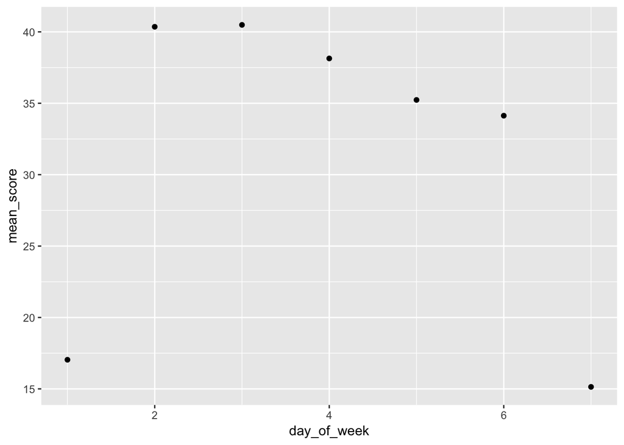

```r
data%>%
  mutate(day_of_week = wday(date_inspection))%>%
  group_by(day_of_week)%>%
  summarize(mean_score = mean(score,na.rm = T))%>%
  ggplot(aes(day_of_week,mean_score))+
  geom_point()
```

This result is not surprising (as most of the inspections take place during the week) instead of on a weekend (day1=Sunday, day7=Saturday).

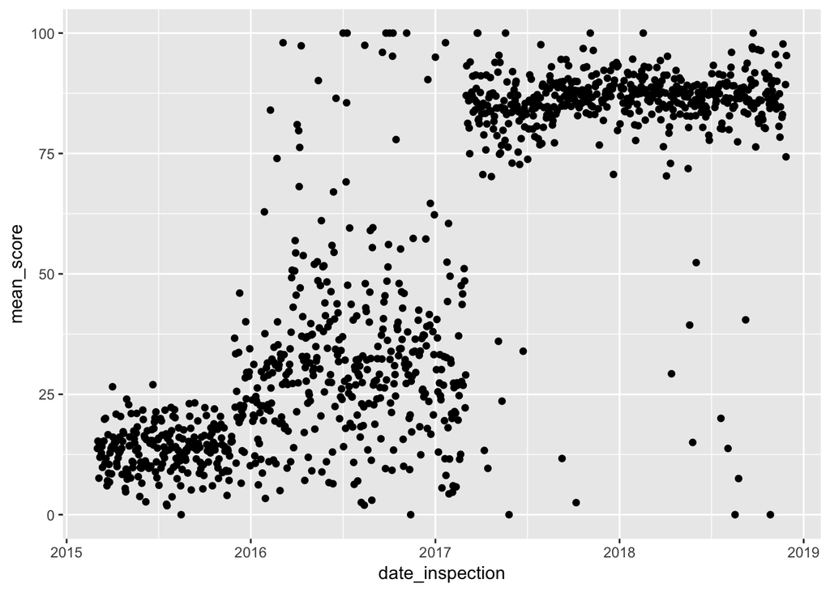

```r
data%>%
  group_by(date_inspection)%>%
  summarize(mean_score= mean(score,na.rm=T))%>%
  ggplot(aes(date_inspection,mean_score))+
  geom_point()
```

There is a huge jump in average scores from early to late 2017. Let us check if this is linked to the County in which the scores are based.

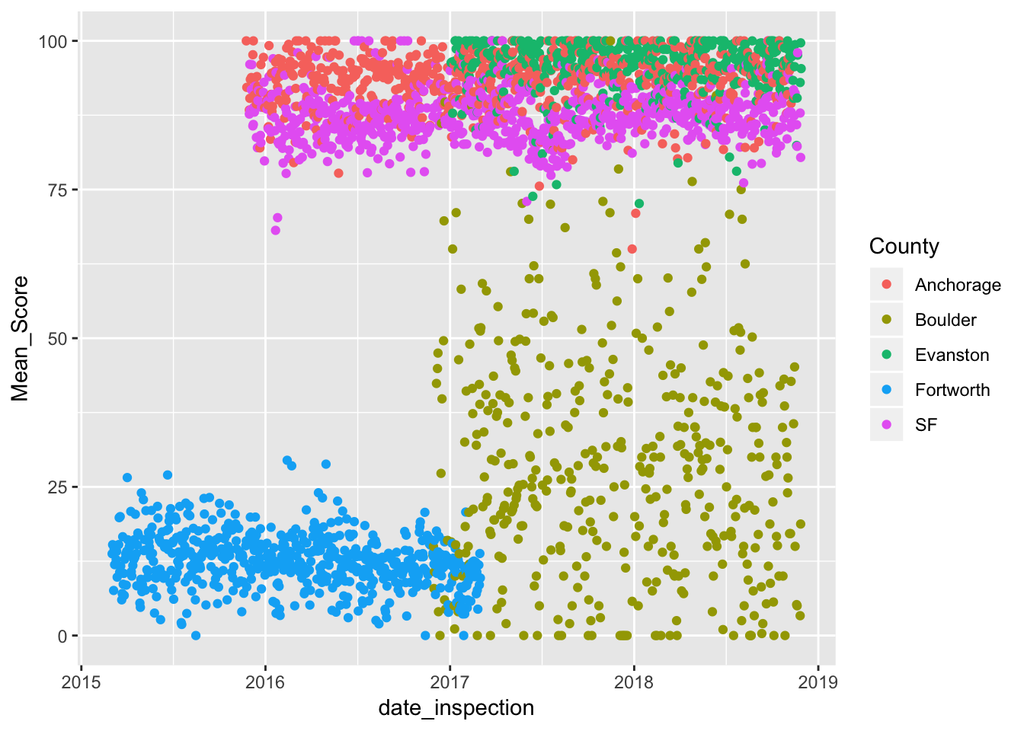

```r
data%>%
  group_by(date_inspection,County)%>%
  summarize(mean_score= mean(score,na.rm=T))%>%
  ggplot(aes(date_inspection,mean_score,color=County))+
  geom_point()+
  labs(y="Mean_Score")
```

The year of inspection gives significant understanding as to why there is a massive jump in mean scores. Initially, from 2015-2016, only Fortworth was reported. Then, when SF and Anchorage started getting recorded in 2016, you see a slight increase in mean scores. Finally, when Fortworth was no longer being reported, Anchorage, Evanston and Sf pulled up the mean scores significantly (there were far fewer data points in Boulder as opposed to the rest). See the statistic below to see the exact difference in data points.

```r
nrow(data%>%
       filter(County=='Anchorage'|County=='SF'|County == 'Evanston'))
```

```
## [1] 155857
```

```r
nrow(data%>%
       filter(County=='Boulder'))
```

```
## [1] 5664
```

#### Modelling the Data

A huge limitation of our data set is that the data was not collected in a standardized period of time across counties. Since it’s hard to find a pattern over years, we have to model each one separately.

```r
county_model <- function(df) {
  lm(mean_score ~ date_inspection, data = df)
}

score_by_county <- data %>%
  #grouping by county
  group_by(County) %>%
  mutate(mean_score=mean(score))%>%
  #each county will have its own dataset
  nest()

score_by_county <- score_by_county %>%
  mutate(model = map(data, county_model))

score_by_county <- score_by_county %>%
  mutate(
    #use map like before to map func each row in data set
    resids = map2(data, model, add_residuals)
  )

score_by_county
```

```
## # A tibble: 5 x 4
##   County    data                    model    resids
##   <fct>     <list>                  <list>   <list>
## 1 Evanston  <tibble [22,276 x 16]>  <S3: lm> <tibble [22,276 x 17]>
## 2 Anchorage <tibble [14,163 x 16]>  <S3: lm> <tibble [14,163 x 17]>
## 3 SF        <tibble [119,418 x 16]> <S3: lm> <tibble [119,418 x 17]>
## 4 Fortworth <tibble [333,628 x 16]> <S3: lm> <tibble [333,628 x 17]>
## 5 Boulder   <tibble [5,664 x 16]>   <S3: lm> <tibble [5,664 x 17]>
```

```r
glance_coefs <- score_by_county %>%
  #broom:tidy gives you info about estimates, std. error and statistic
  mutate(glance = map(model, broom::tidy)) %>%
  unnest(glance, .drop = TRUE)
glance_coefs
```

```
## # A tibble: 10 x 6
##    County    term             estimate std.error statistic p.value
##    <fct>     <chr>               <dbl>     <dbl>     <dbl>   <dbl>
##  1 Evanston  (Intercept)      9.46e+ 1  2.10e-11  4.50e+12  0
##  2 Evanston  date_inspection -2.13e-15  1.20e-15 -1.77e+ 0  0.0767
##  3 Anchorage (Intercept)      9.19e+ 1  1.20e-11  7.65e+12  0
##  4 Anchorage date_inspection -5.44e-16  6.96e-16 -7.81e- 1  0.435
##  5 SF        (Intercept)      8.65e+ 1  1.08e-11  8.04e+12  0
##  6 SF        date_inspection  7.71e-16  6.22e-16  1.24e+ 0  0.215
##  7 Fortworth (Intercept)      1.30e+ 1  3.48e-12  3.74e+12  0
##  8 Fortworth date_inspection -3.50e-16  2.06e-16 -1.70e+ 0  0.0898
##  9 Boulder   (Intercept)      3.50e+ 1  5.45e-12  6.43e+12  0
## 10 Boulder   date_inspection  1.97e-16  3.12e-16  6.33e- 1  0.527
```

```r
glance_r2 <- score_by_county %>%
  #broom:tidy gives you info about estimates, std. error and statistic
  mutate(glance = map(model, broom::glance)) %>%
  unnest(glance, .drop = TRUE)
glance_r2
```

```
## # A tibble: 5 x 12
##   County r.squared adj.r.squared    sigma statistic p.value    df logLik
##   <fct>      <dbl>         <dbl>    <dbl>     <dbl>   <dbl> <int>  <dbl>
## 1 Evans~     0.500         0.500 3.29e-11    22274.       0     2 5.06e5
## 2 Ancho~     0.500         0.500 2.47e-11    14161.       0     2 3.26e5
## 3 SF         0.500         0.500 6.55e-11   119416.       0     2 2.63e6
## 4 Fortw~     0.500         0.500 2.52e-11   333626.       0     2 7.67e6
## 5 Bould~     0.500         0.500 4.76e-12     5662.       0     2 1.40e5
## # ... with 4 more variables: AIC <dbl>, BIC <dbl>, deviance <dbl>,
## #   df.residual <int>
```

### Key Takeaways

1. There are significant distinctions in scores by county (Evanston has the highest mean score, Fortworth has the lowest)
2. Distribution of the scores are higher towards the lower and upper ends (0,100). Very few scores actually score 50 (or average)
3. The most common words used in the descriptions differ by county but are not super representative of why the counties were scored a certain way (mostly talk about food, surfaces etc.) but it hard to reach a conclusive judgement on quality (no words like bad, good etc.)
4. Mean county scores don’t change over years. If the county recieves a certain score one year, they are likely to recieve the same the next. This is interesting because you’d expect the counties that score less to be able to improve and bump their scores or counties that score high to have “bad years” where they don’t score that well.

### Limitations of Data and Future Work

Limitation 1:

Counties aren’t scored in the same time frame. It is therefore hard to reach conclusive results about yearwise scores (just because scores jump significantly post 2017, it doesn’t mean restaurants are improving across the board – they were just looking at a completely different set of counties).

Future Work 1:

In the future, it could be helpful if Yelp/the counties released scores pertinent to a constant time frame. Or we can filter data to choose only those counties that were inspected in the same years.

Limitation 2:

This dataset may use counties that are pretty widespread geographically so you can’t see patterns that occur in counties that are closer to each other (state/coast wise comparison).

Future Work 2:

If this analysis was to be expanded, we could look at more counties around the key counties like Evanston or Fortworth to get trends to see if nearby restaurants follow the same trends or if this county is a one of.

Limitation 3:

The variable code was hard to work with because it was very difficult for me to find a standardized FDA health code chart to work with especially as the years of inspection differed so significantly.

Future Work 4:

If we could potentially match the codes in this dataset to the codes by the FDA, we could get a better understanding of the health standard they were violating and thereby why they recieved the certain score that they did. Also since this analysis was primarily to do a county-wise analysis, it did not tell you the specifics of the restaurants (cuisine, size etc.) It would be very cool if we could expand this analysis to find trends in scores by restaurants.